# psychopy_stats

[figure not shown]

## Using the Python Pandas library to explore the data

**Learning objectives:**

- Use shell commands to navigate to the data folder
- Import Psychopy data into the Jupyter Notebook
- Generate descriptive statistics
- Plot some comparisons by grouping data

Here we are using iPython version 3 in the [iPython Jupyter Notebook](http://ipython.org/notebook.html)

We will set up the notebook and load the additional software library we will need - "Pandas".

```python
import pandas as pd
```

The Jupyter Notebook understands shell commands as well, we'll use this to find our data. We'll use the exclamation mark to signal that what follows is a shell command rather than Python code.

```python
# print working directory
!pwd
```

```
/Users/talithaford/Dropbox/Conference-Workshop/ResBaz/2016/psychopy_lesson
```

```python
# list files in 'data/'
!ls data/
```

```
tf1_visneuro_2016_Feb_02_1234.csv    tf_visneuro_2016_Feb_02_1218.psydat
tf1_visneuro_2016_Feb_02_1234.log    tf_visneuro_2016_Feb_02_1233.csv
tf1_visneuro_2016_Feb_02_1234.psydat tf_visneuro_2016_Feb_02_1233.log
tf_visneuro_2016_Feb_02_1218.csv     tf_visneuro_2016_Feb_02_1233.psydat
tf_visneuro_2016_Feb_02_1218.log
```

We can use the 'read_csv' function of Pandas to read the datafile into a pandas DataFrame. A DataFrame will look familiar to anyone who has used Excel or SPSS.

```python
# read the csv
df = pd.read_csv('data/tf1_visneuro_2016_Feb_02_1234.csv')
# print the first 5 lines of the DataFrame
df.head()
```

|  | correct_ans | images | type_of_image | loop.thisRepN | loop.thisTrialN | loop.thisN | loop.thisIndex | key_resp_3.keys | key_resp_3.corr | key_resp_3.rt | date | frameRate | expName | session | participant | Unnamed: 15 |
| --- | --- | --- | --- | --- | --- | --- | --- | --- | --- | --- | --- | --- | --- | --- | --- | --- |
| 0 | up | images/egg_hog.jpeg | hog | 0 | 0 | 0 | 6 | up | 1 | 0.633549 | 2016_Feb_02_1234 | 60.205465 | visneuro | 1 | tf1 | NaN |
| 1 | right | images/cat_eyes.jpeg | cat | 0 | 1 | 1 | 3 | right | 1 | 0.550386 | 2016_Feb_02_1234 | 60.205465 | visneuro | 1 | tf1 | NaN |
| 2 | left | images/gorilla_tongue.jpeg | gorilla | 0 | 2 | 2 | 2 | left | 1 | 0.600392 | 2016_Feb_02_1234 | 60.205465 | visneuro | 1 | tf1 | NaN |
| 3 | up | images/santa_hog.jpeg | hog | 0 | 3 | 3 | 9 | up | 1 | 0.600248 | 2016_Feb_02_1234 | 60.205465 | visneuro | 1 | tf1 | NaN |
| 4 | right | images/ear_muffs_cat.jpeg | cat | 0 | 4 | 4 | 4 | right | 1 | 0.749853 | 2016_Feb_02_1234 | 60.205465 | visneuro | 1 | tf1 | NaN |

```python
# drop the first row (under the header)
# the inplace option allows us to makes changes to the dataframe directly
# rather than having to save the output to another variable
df.drop(0, inplace=True)
df.head()
```

|  | correct_ans | images | type_of_image | loop.thisRepN | loop.thisTrialN | loop.thisN | loop.thisIndex | key_resp_3.keys | key_resp_3.corr | key_resp_3.rt | date | frameRate | expName | session | participant | Unnamed: 15 |
| --- | --- | --- | --- | --- | --- | --- | --- | --- | --- | --- | --- | --- | --- | --- | --- | --- |
| 1 | right | images/cat_eyes.jpeg | cat | 0 | 1 | 1 | 3 | right | 1 | 0.550386 | 2016_Feb_02_1234 | 60.205465 | visneuro | 1 | tf1 | NaN |
| 2 | left | images/gorilla_tongue.jpeg | gorilla | 0 | 2 | 2 | 2 | left | 1 | 0.600392 | 2016_Feb_02_1234 | 60.205465 | visneuro | 1 | tf1 | NaN |
| 3 | up | images/santa_hog.jpeg | hog | 0 | 3 | 3 | 9 | up | 1 | 0.600248 | 2016_Feb_02_1234 | 60.205465 | visneuro | 1 | tf1 | NaN |
| 4 | right | images/ear_muffs_cat.jpeg | cat | 0 | 4 | 4 | 4 | right | 1 | 0.749853 | 2016_Feb_02_1234 | 60.205465 | visneuro | 1 | tf1 | NaN |
| 5 | up | images/marshmallow_hog.jpeg | hog | 0 | 5 | 5 | 8 | up | 1 | 0.766511 | 2016_Feb_02_1234 | 60.205465 | visneuro | 1 | tf1 | NaN |

```python
# drop all colums with NA's
df.dropna(axis=1, inplace=True, how='all')
df.head()
```

|  | correct_ans | images | type_of_image | loop.thisRepN | loop.thisTrialN | loop.thisN | loop.thisIndex | key_resp_3.keys | key_resp_3.corr | key_resp_3.rt | date | frameRate | expName | session | participant |
| --- | --- | --- | --- | --- | --- | --- | --- | --- | --- | --- | --- | --- | --- | --- | --- |
| 1 | right | images/cat_eyes.jpeg | cat | 0 | 1 | 1 | 3 | right | 1 | 0.550386 | 2016_Feb_02_1234 | 60.205465 | visneuro | 1 | tf1 |
| 2 | left | images/gorilla_tongue.jpeg | gorilla | 0 | 2 | 2 | 2 | left | 1 | 0.600392 | 2016_Feb_02_1234 | 60.205465 | visneuro | 1 | tf1 |
| 3 | up | images/santa_hog.jpeg | hog | 0 | 3 | 3 | 9 | up | 1 | 0.600248 | 2016_Feb_02_1234 | 60.205465 | visneuro | 1 | tf1 |
| 4 | right | images/ear_muffs_cat.jpeg | cat | 0 | 4 | 4 | 4 | right | 1 | 0.749853 | 2016_Feb_02_1234 | 60.205465 | visneuro | 1 | tf1 |
| 5 | up | images/marshmallow_hog.jpeg | hog | 0 | 5 | 5 | 8 | up | 1 | 0.766511 | 2016_Feb_02_1234 | 60.205465 | visneuro | 1 | tf1 |

```python
# save out new dataframe as csv
df.to_csv('data/ID001.csv', index=False)

# to read back in you can use:
#df = pd.read_csv('data/ID001.csv')
```

# Visualising the data

**Now that we have cleaned the data, it might be helpful to visualise it.  
To do this we need to import some packages. **

**Matplotlib** is a Python library that produces quality figures and graphs from data.  
**Seaborn** is a Python library based on matplotlib, which provides additional graphical modifications for matplotlib figures and graphs.

```python
import matplotlib as mpl
import matplotlib.pyplot as plt
import seaborn as sns # seaborn

# to see the plots in the workspace we use:
%matplotlib inline

# these are seaborn commands, they are used for asthetics
sns.set_color_codes()
sns.set_style('whitegrid')
```

Create a basic plot of all the columns

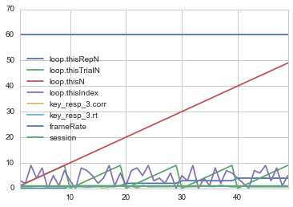

```python
df.plot()
```

The plot is good, but it doesn't actually tell us much.  
Let's used the package matplotlib.pyplot ('plt'), but first, find out what the function 'plot' in the package does.

```python
plt.plot?
```

To plot a single column (e.g. reaction time), enter the name of the column (the header) as a **string** in square brackets immediately following the dataframe label as shown below. The column header is the 'index' for that column. In this example, the plot will include the legend.

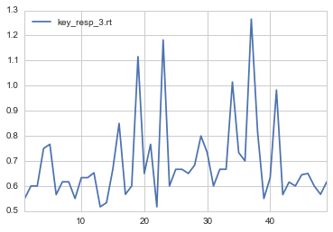

```python
df['key_resp_3.rt'].plot(legend=True)
```

Seaborn (sns) has a nice distribution plot to visualise whether the responses are normally disributed.

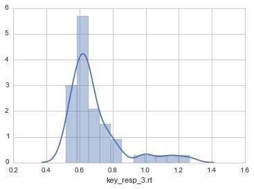

```python
sns.distplot(df['key_resp_3.rt'])
```

```python
df_clean = df[df['key_resp_3.rt'] < .9]
```

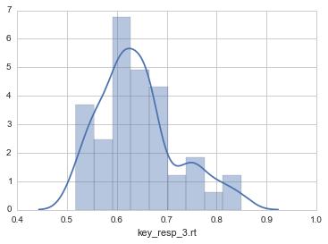

```python
sns.distplot(df_clean['key_resp_3.rt'])
```

We can plot the reaction time by the type of image by including the column name 'type_of_image' in parentheses before the index.

```
type_of_image
cat        Axes(0.125,0.125;0.775x0.775)
gorilla    Axes(0.125,0.125;0.775x0.775)
hog        Axes(0.125,0.125;0.775x0.775)
Name: key_resp_3.rt, dtype: object
```

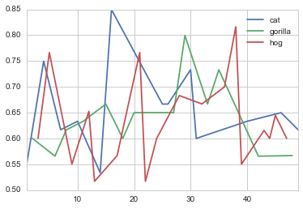

```python
df_clean.groupby('type_of_image')['key_resp_3.rt'].plot(legend=True)
```

Creating a variable that groups reation time by the animal type gives some more functionality

```python
animal_type_group = df_clean.groupby('type_of_image')['key_resp_3.rt']
```

[output not shown]

[figure not shown]

```python
# then we can plot that variable
animal_type_group.plot(legend = True)
```

This doesn't tell us much, but we can now print out the statistics for that variable.

```python
animal_type_group.mean()
```

```
type_of_image
cat        0.653995
gorilla    0.639744
hog        0.634237
Name: key_resp_3.rt, dtype: float64
```

```python
print('Mean: ',animal_type_group.mean())
print('SD: ',animal_type_group.std())
```

```
('Mean: ', type_of_image
cat        0.653995
gorilla    0.639744
hog        0.634237
Name: key_resp_3.rt, dtype: float64)
('SD: ', type_of_image
cat        0.084515
gorilla    0.068218
hog        0.086569
Name: key_resp_3.rt, dtype: float64)
```

We can also visualise the reaction time by the type of image as a boxplot

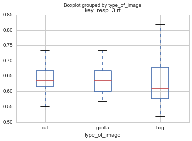

```python
df_clean.boxplot('key_resp_3.rt',by = 'type_of_image',)
```

and save plot to the current working directory

```python
plt.savefig('ID001_boxplot.png')
```